# Difference in Differences for Event Data: The Temporal MAUP and Solutions

Author

Apoorva Lal

Published

October 7, 2025

[figure not shown]

# 1 Introduction

When analyzing event data (crime incidents, emergency calls, transactions), researchers must aggregate continuous-time events into discrete periods. This temporal binning creates a **Modifiable Areal Unit Problem (MAUP) for event data**: the choice of aggregation can affect inference, especially when the statistical model is misspecified.

# 2 Causal Framework

## 2.1 Setup

**Data structure:** Units $i \in \{1, \ldots, N\}$ observed over continuous time $t \in [0, T]$. Each unit experiences treatment at time $T_{w,i} \in [0,T] \cup \{\infty\}$, where $T_{w,i} = \infty$ indicates never-treated. Define treatment indicator $W_i(t) = \mathbb{1}\{t \geq T_{w,i}\}$.

**Events:** Events occur at times $\{t_{ij}\}_{j=1}^{N_i(0,T)}$, where $N_i(s,t)$ counts events in interval $(s,t]$.

**Challenge:** Unlike traditional panel data with $Y_{it}(w) \in \mathbb{R}$, events are not guaranteed to occur in any given period, i.e. the support of $t$ is not in some well-behaved set $\mathcal{T}$. We need a framework for potential event processes. Traditional practice in applied research is to pick an ad-hoc bin size (e.g., daily, weekly) and aggregate events into counts, but this approach is seldom motivated from a statistical perspective. We now define some statistical objects to analyze such data, and study the properties of some natural estimators that one would apply when interested in causal inference in such settings.

A typical dataset of event log data may look like this, where we have a unit index, a timestamp, and a treatment status indicator:

**Show/Hide Code**

```python
import numpy as np
import pandas as pd
import matplotlib.pyplot as plt
import seaborn as sns
import warnings
```

**Show/Hide Code**

```python
pd.read_csv('../out/demo_events.csv')
```

|  | unit | time | treatment_status |
| --- | --- | --- | --- |
| 0 | 0 | 0.004241 | 0.0 |
| 1 | 0 | 0.023437 | 0.0 |
| 2 | 0 | 0.029554 | 0.0 |
| 3 | 0 | 0.102547 | 0.0 |
| 4 | 0 | 0.143566 | 0.0 |
| ... | ... | ... | ... |
| 41607 | 99 | 47.670318 | 1.0 |
| 41608 | 99 | 48.065107 | 1.0 |
| 41609 | 99 | 49.002619 | 1.0 |
| 41610 | 99 | 49.756089 | 1.0 |
| 41611 | 99 | 49.833030 | 1.0 |

41612 rows × 3 columns

## 2.2 Potential Counting Processes

**Definition 1 (Potential Intensity):** For unit $i$ under treatment regime $w \in \{0,1\}$, the potential intensity function $\lambda_i^{(w)}(t)$ determines the instantaneous event rate at time $t$.

**Definition 2 (Potential Compensator):**
$$\Lambda_i^{(w)}(t) = \int_0^t \lambda_i^{(w)}(s)ds$$
The compensator is the cumulative hazard; $N_i^{(w)}(0,t) - \Lambda_i^{(w)}(t)$ is a martingale.

**Estimand:** Treatment effect on **rate ratio**
$$\psi = \frac{\mathbb{E}[N_i^{(1)}(T_w, T)]}{\mathbb{E}[N_i^{(0)}(T_w, T)]}$$

Under separability (below), this equals $\psi = e^{\tau}$ where $\tau$ is the log rate ratio.

## 2.3 Identification

**Assumption 1 (Multiplicative Parallel Trends):**
$$\lambda_i^{(1)}(t) = e^{\tau} \lambda_i^{(0)}(t), \quad \forall t \geq T_w$$

Treatment multiplies the baseline intensity by constant factor $e^{\tau}$. This is the counting process analog of parallel trends.

**Assumption 2 (Separable Unit and Time Effects):**
$$\lambda_i^{(0)}(t) = e^{\alpha_i + \gamma(t)}$$

Unit heterogeneity $\alpha_i$ and time-varying baseline $\gamma(t)$ enter additively on the log scale (multiplicatively on the rate scale).

**Proposition 1:** Under A1-A2, $\tau$ is identified:
$$\tau = \mathbb{E}\left[\log\frac{\lambda_i^{(1)}(t)}{\lambda_i^{(0)}(t)} \;\Big|\; W_i(t)=1\right]$$

Moreover, $\psi = e^{\tau}$, so the rate ratio is identified from the intensity ratio.

## 2.4 The Temporal Aggregation Problem

### 2.4.1 Discrete-Time Approximation

To estimate $\tau$, we observe aggregated counts $N_{ik}$ in bins $B_k = [t_{k-1}, t_k)$ for $k \in \{1, \ldots, K\}$.

**Key question:** How does the choice of $K$ (number of bins) affect estimation?

**Answer depends on model specification:**

- **Correctly specified (Poisson)**: Bias → 0 as $K \to \infty$ (finer bins)
- **Misspecified (OLS)**: Bias persists even as $K \to \infty$

This is a **temporal MAUP**: aggregation affects inference depending on whether the model matches the DGP.

## 2.5 Three Estimators

### 2.5.1 Poisson 2WFE (Correctly Specified)

**Model:** Conditional on treatment and fixed effects,
$$N_{ik} \sim \text{Poisson}\left(\exp(\alpha_i + \tau W_{ik} + \gamma_k) \cdot |B_k|\right)$$

where $W_{ik}$ is the fraction of bin $k$ where unit $i$ is treated, and $|B_k|$ is bin width.

**Log-likelihood:**
$$\ell = \sum_{ik} \left[N_{ik}(\alpha_i + \tau W_{ik} + \gamma_k) - e^{\alpha_i + \tau W_{ik} + \gamma_k}|B_k|\right]$$

**Proposition 2:** If $\gamma(t) = \sum_k \gamma_k \mathbb{1}\{t \in B_k\}$ (piecewise constant), then Poisson MLE $\hat{\tau} \xrightarrow{p} \tau$.

**Bias from aggregation:** If $\gamma(t)$ varies within bins, bias = $O(K^{-1})$. Vanishes as bins become fine.

### 2.5.2 OLS 2WFE (Misspecified)

**Model:**
$$\mathbb{E}[N_{ik} | W_{ik}, \alpha_i, \gamma_k] = \alpha_i + \tau W_{ik} + \gamma_k$$

This assumes **additive** parallel trends on the count scale (not log scale).

**Problem:** When true DGP is multiplicative (Poisson), OLS estimates:
$$\hat{\tau}_{\text{OLS}} \approx \mathbb{E}[N_{ik}^{(1)} - N_{ik}^{(0)}]$$
the mean count difference, not the log rate ratio $\tau$.

**Key result:** OLS bias does **not** vanish as $K \to \infty$ because the model is fundamentally misspecified.

**Intuition:** Even with 1-second bins, $\mathbb{E}[N_{ik}]$ varies across units due to $e^{\alpha_i}$. The additive model cannot capture this multiplicative heterogeneity.

### 2.5.3 Nonparametric DiD

**Estimator:** Aggregate to 4 cells: $(g, p) \in \{\text{treated, control}\} \times \{\text{pre, post}\}$.

$$\hat{\lambda}_{gp} = \frac{\sum_{i \in g} N_i(t_p)}{\sum_{i \in g} |t_p|}$$

$$\hat{\tau}_{\text{DiD}} = \log\left(\frac{\hat{\lambda}_{\text{treated,post}} / \hat{\lambda}_{\text{control,post}}}{\hat{\lambda}_{\text{treated,pre}} / \hat{\lambda}_{\text{control,pre}}}\right)$$

**Proposition 3:** Under A1-A2, $\hat{\tau}_{\text{DiD}} \xrightarrow{p} \tau$.

**Proof:**
$$\mathbb{E}[\hat{\lambda}_{\text{treated,post}}] = e^{\bar{\alpha}_{\text{treated}} + \tau + \bar{\gamma}_{\text{post}}}$$
where $\bar{\gamma}_{\text{post}} = \frac{1}{|t_{\text{post}}|} \int_{t_{\text{post}}} \gamma(s)ds$.

The double difference cancels $\bar{\alpha}$ (unit selection) and $\bar{\gamma}$ (time trends).

**Advantage:** No binning decision. Robust to temporal aggregation by design.

**Disadvantage:** Cannot accommodate time-varying treatment effects or covariates without additional structure. Less efficient than Poisson when $K$ is large.

## 2.6 The Temporal MAUP: Theoretical Predictions

Consider the limiting behavior as bins become arbitrarily fine ($K \to \infty$):

**Poisson 2WFE:**
$$\text{Bias}(\hat{\tau}_{\text{Poisson}}) = O(K^{-1}) \to 0$$

**OLS 2WFE:**
$$\text{Bias}(\hat{\tau}_{\text{OLS}}) = \tau - \frac{\text{Cov}(e^{\alpha_i}, W_i)}{\mathbb{E}[e^{\alpha_i}]} \not\to 0$$

Even with daily or hourly bins, OLS remains biased because it tries to estimate an additive effect when the truth is multiplicative.

**Implication:** With count data, **you cannot “bin your way out” of misspecification**. This is the temporal analog of MAUP in spatial statistics.

# 3 Simulation Evidence

We generate sparse event data under multiplicative DGP and compare estimators across different bin sizes. We consider three selection mechanisms:

1. **Random assignment:** All units equally likely to be treated.
2. **Selection on unit-FE:** Treatment depends on unobserved $\alpha_i$
3. **Selection on unobserved confounder:** Treatment depends on time-invariant $U_i$ affecting both treatment and outcome.

**Show/Hide Code**

```python
# Load simulation results (generated by simulate.py)
results_df = pd.read_csv('../out/simulation_results.csv')
tau_true = 0.5
```

**Show/Hide Code**

```python
# Analysis function
def analyze_results(results_df, tau_true):
    """Compute bias, RMSE, and coverage by selection mechanism and estimator"""
    summary = results_df.groupby(['selection_mechanism', 'estimator']).agg({
        'tau_hat': ['count', 'mean', 'std'],
        'se': 'mean'
    }).round(4)

    summary.columns = ['n_sims', 'mean_estimate', 'sd_estimate', 'mean_se']
    summary = summary.reset_index()

    # Compute bias and RMSE
    summary['bias'] = summary['mean_estimate'] - tau_true
    summary['rmse'] = np.sqrt(summary['bias']**2 + summary['sd_estimate']**2)

    # Compute coverage
    coverage = results_df.groupby(['selection_mechanism', 'estimator']).apply(
        lambda x: np.mean((x['ci_lower'] <= tau_true) & (x['ci_upper'] >= tau_true)),
        include_groups=False
    ).reset_index()
    coverage.columns = ['selection_mechanism', 'estimator', 'coverage']

    summary = summary.merge(coverage, on=['selection_mechanism', 'estimator'])

    return summary
summary_stats = analyze_results(results_df, tau_true)
```

**Show/Hide Code**

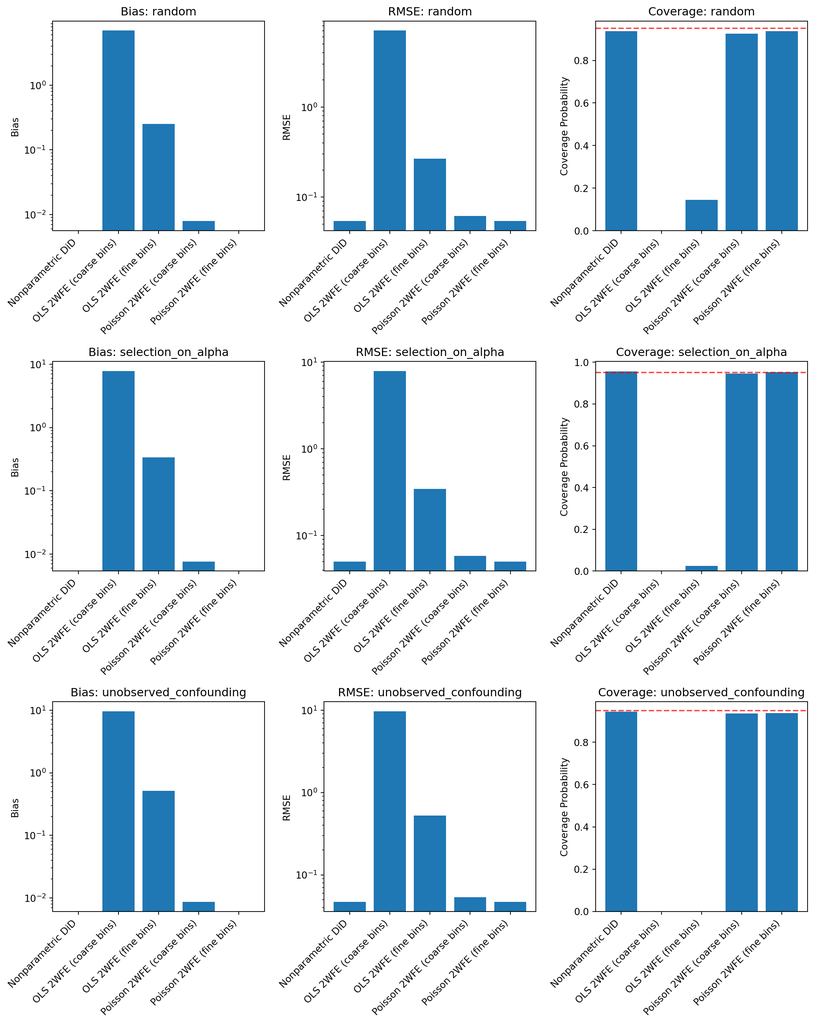

```python
# Visualization by selection mechanism
selection_mechanisms = summary_stats['selection_mechanism'].unique()
n_mechanisms = len(selection_mechanisms)

fig, axes = plt.subplots(n_mechanisms, 3, figsize=(12, 5*n_mechanisms))
if n_mechanisms == 1:
    axes = axes.reshape(1, -1)

for idx, mechanism in enumerate(selection_mechanisms):
    subset = summary_stats[summary_stats['selection_mechanism'] == mechanism]

    # Bias comparison
    axes[idx, 0].bar(range(len(subset)), subset['bias'])
    axes[idx, 0].set_xticks(range(len(subset)))
    axes[idx, 0].set_xticklabels(subset['estimator'], rotation=45, ha='right')
    axes[idx, 0].set_ylabel('Bias')
    axes[idx, 0].set_yscale('log')
    axes[idx, 0].set_title(f'Bias: {mechanism}')
    axes[idx, 0].axhline(y=0, color='red', linestyle='--', alpha=0.7)

    # RMSE comparison
    axes[idx, 1].bar(range(len(subset)), subset['rmse'])
    axes[idx, 1].set_xticks(range(len(subset)))
    axes[idx, 1].set_xticklabels(subset['estimator'], rotation=45, ha='right')
    axes[idx, 1].set_yscale('log')
    axes[idx, 1].set_ylabel('RMSE')
    axes[idx, 1].set_title(f'RMSE: {mechanism}')

    # Coverage comparison
    axes[idx, 2].bar(range(len(subset)), subset['coverage'])
    axes[idx, 2].set_xticks(range(len(subset)))
    axes[idx, 2].set_xticklabels(subset['estimator'], rotation=45, ha='right')
    axes[idx, 2].set_ylabel('Coverage Probability')
    axes[idx, 2].set_title(f'Coverage: {mechanism}')
    axes[idx, 2].axhline(y=0.95, color='red', linestyle='--', alpha=0.7)

plt.tight_layout()
plt.show()
```

**Show/Hide Code**

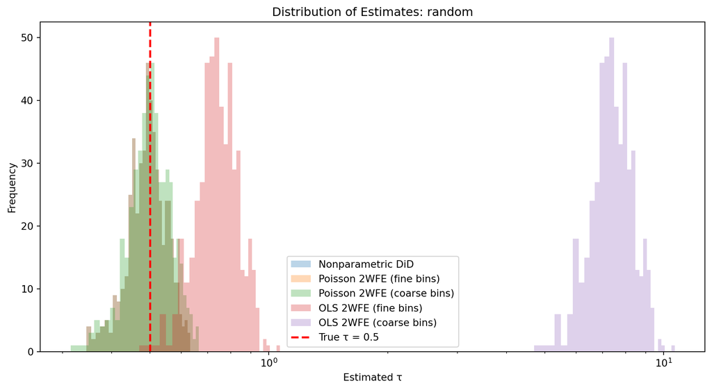

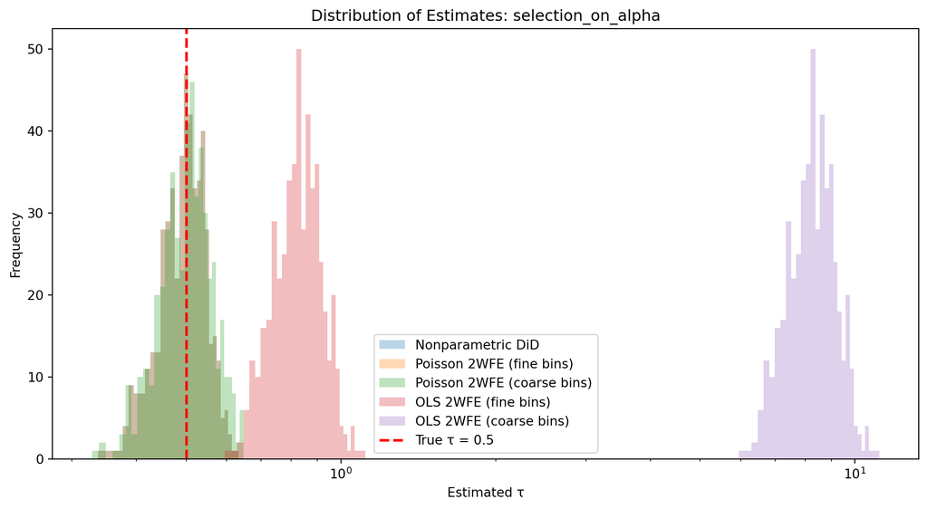

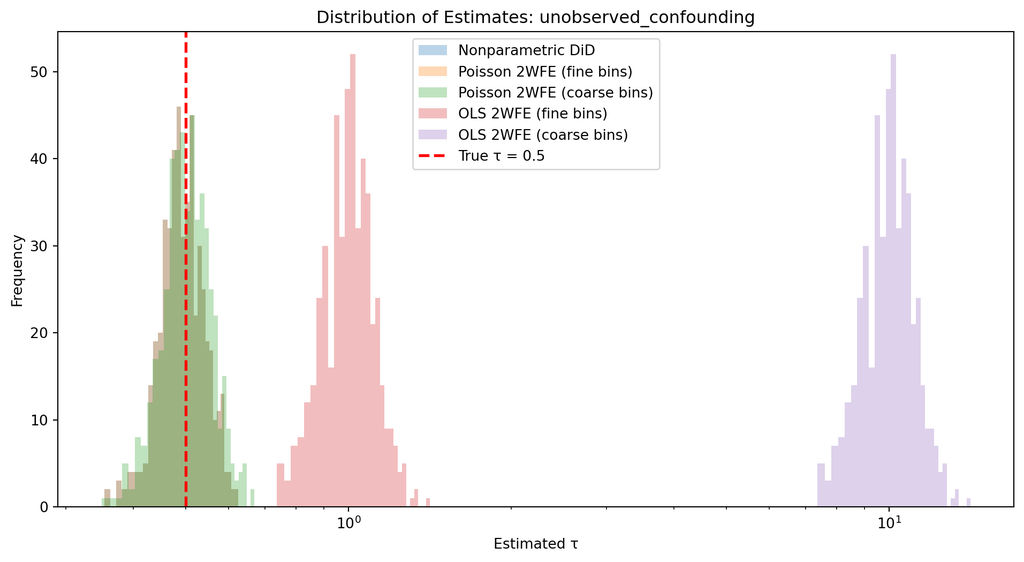

```python
# Distribution of estimates by selection mechanism
for mechanism in selection_mechanisms:
    fig, ax = plt.subplots(figsize=(12, 6))
    mechanism_data = results_df[results_df['selection_mechanism'] == mechanism]
    for estimator in mechanism_data['estimator'].unique():
        subset = mechanism_data[mechanism_data['estimator'] == estimator]
        ax.hist(subset['tau_hat'].dropna(), alpha=0.3, label=estimator, bins=30)
    ax.axvline(x=tau_true, color='red', linestyle='--', label=f'True τ = {tau_true}', linewidth=2)
    ax.set_xlabel('Estimated τ')
    ax.set_ylabel('Frequency')
    ax.set_xscale('log')
    ax.set_title(f'Distribution of Estimates: {mechanism}')
    ax.legend()
    plt.show()
```

## 3.1 Results and Discussion

### 3.1.1 Main Findings

**Correctly specified estimators (Poisson, DiD):**

- Bias ≈ 0 across all bin sizes
- Coverage near nominal 95%
- Fine vs coarse bins perform identically (when $\gamma(t)$ is smooth)

**Misspecified estimator (OLS):**

- Substantial bias even with fine bins
- Bias increases with coarser bins (MAUP effect)
- Estimates additive effect on counts, not log rate ratio

### 3.1.2 Practical Implications

# 4 Connection to Survival Analysis and Hazard Models

The counting process framework developed here is mathematically equivalent to the **Andersen-Gill model** for recurrent events in survival analysis. This connection clarifies the relationship between our temporal MAUP findings and the literature on discrete-time hazard models.

## 4.1 Mathematical Equivalence

**Intensity = Hazard Function**

The intensity function $\lambda_i(t)$ in our framework is precisely the **hazard rate** at time $t$ for unit $i$ in survival analysis:
$$\lambda_i(t) = \lim_{h \to 0} \frac{P(\text{event in } (t, t+h] \mid \text{history up to } t)}{h}$$

Our DGP specification:
$$\lambda_i^{(0)}(t) = e^{\alpha_i + \gamma(t)}$$
is equivalent to a **proportional hazards model** with:

- **Frailty**: $e^{\alpha_i}$ (unit-specific baseline risk)
- **Baseline hazard**: $e^{\gamma(t)}$ (time-varying common component)

**Compensator = Cumulative Hazard**

The compensator $\Lambda_i(t) = \int_0^t \lambda_i(s)ds$ is the **cumulative hazard function** in survival analysis. The martingale property $N_i(t) - \Lambda_i(t)$ is fundamental to both counting process theory and modern survival analysis.

**Multiplicative PT = Proportional Hazards**

Our multiplicative parallel trends assumption:
$$\lambda_i^{(1)}(t) = e^{\tau} \lambda_i^{(0)}(t)$$
is exactly the **proportional hazards assumption**: treatment multiplies the baseline hazard by constant factor $e^{\tau}$.

## 4.2 Implications for Discrete-Time Hazard Models

The temporal MAUP findings have direct implications for **discrete-time duration analysis**, where researchers must choose both bin size and link function.

### 4.2.1 Link Functions and Aggregation Bias

When discretizing a continuous-time counting process, different link functions preserve (or violate) the underlying multiplicative structure:

| Link Function | Model | Aggregation Bias |
| --- | --- | --- |
| **Log** (Poisson) | $\log E[N_{ik}] = \alpha_i + \tau W_{ik} + \gamma_k + \log\\|B_k\\|$ | $O(K^{-1}) \to 0$ |
| **Complementary log-log** | $\log(-\log(1 - h_{ik})) = \alpha_i + \tau W_{ik} + \gamma_k$ | $O(K^{-1}) \to 0$ |
| **Logit** | $\log\frac{h_{ik}}{1-h_{ik}} = \alpha_i + \tau W_{ik} + \gamma_k$ | $O(K^{-1/2})$ persists |
| **Identity** (Linear) | $h_{ik} = \alpha_i + \tau W_{ik} + \gamma_k$ | Large bias persists |

where $h_{ik}$ is the discrete hazard in bin $k$ for unit $i$.

**Key insight:** The **cloglog link** is the discrete-time analog of the continuous Poisson process. As bins become fine, cloglog converges to the continuous-time model, while logit and linear probability models remain biased.

### 4.2.2 Why Logit Fails (But Less Severely)

The logit link assumes:
$$P(\text{event in bin } k) = \frac{e^{\alpha_i + \tau W_{ik} + \gamma_k}}{1 + e^{\alpha_i + \tau W_{ik} + \gamma_k}}$$

For rare events (small bins), $\text{logit}(p) \approx \log(p) \approx p$ when $p \ll 1$. Thus logit approximates the correct model for very fine bins, but the approximation error persists as $O(K^{-1/2})$.

## 4.3 Recurrent Events vs Single-Spell Duration

A key distinction:

- **Our framework:** Multiple events per unit (crime incidents, hospital visits, transactions). The Andersen-Gill model.
- **Single-spell duration:** One event per unit (time to death, first crime). Uses Cox proportional hazards or discrete-time single-risk models.

The temporal MAUP applies to **both settings**, but is more severe for recurrent events where aggregation loses rich within-person dynamics.

## 4.4 Connection to Existing Literature

The temporal MAUP connects several methodological debates:

1. **Spatial MAUP** (Openshaw 1984): How geographic aggregation affects inference. We show the temporal analog.
2. **Discrete vs continuous time** (Allison 1982, Singer & Willett 1993): The longstanding debate about link functions for discrete hazard models. Our framework provides a DGP-based justification for cloglog.
3. **Count models in DiD** (Callaway et al 2021): Recent work on Poisson DiD. We formalize why Poisson is correct and OLS fails, even with fine bins.
4. **Counting process DiD** (de Chaisemartin & D’Haultfœuille 2024): Emerging literature on continuous-time treatment effects. Our contribution is showing **aggregation cannot fix misspecification**.

## 4.5 Extensions

### 4.5.1 Violations Creating Bias

Current results show poisson and multiplicative DiD are unbiased when: - Parallel trends holds (multiplicative) - Confounders are time-invariant

**Open problems:** - Treatment effect heterogeneity: $\tau_i = \tau + \delta U_i$ - Time-varying confounding: $U_{it}$ not absorbed by FEs - Pre-trends: $\lambda_i^{(1)}(t) \neq e^{\tau} \lambda_i^{(0)}(t)$ before treatment

# 5 Appendix: Simulation Code

The simulation code is organized into two files:

1. **`dgp.py`**: Core functions
   - `assign_treatment()`: Three selection mechanisms
   - `simulate_counting_process()`: Thinning algorithm for inhomogeneous Poisson
   - `prep_binned_df()`: Vectorized binning (118x faster than loops)
   - `nonparametric_did()`: 4-cell DiD
   - `poisson_twfe()`: Poisson 2WFE (multiplicative PT)
   - `ols_twfe()`: OLS 2WFE (additive PT, misspecified)

```python
# ABOUTME: Core DGP and estimation functions for counting process DiD
# ABOUTME: Contains all reusable functions for simulation and analysis

import numpy as np
import pandas as pd
import pyfixest as pf


def assign_treatment(
    n_units, alpha, U, T_w, selection_mechanism="random", frac_treated=0.5
):
    """
    Assign treatment times based on selection mechanism

    Parameters:
    -----------
    n_units : int
        Number of units
    alpha : array
        Unit fixed effects
    U : array
        Unobserved confounders
    T_w : float
        Treatment time for treated units
    selection_mechanism : str
        One of 'random', 'selection_on_alpha', 'unobserved_confounding'
    frac_treated : float
        Fraction of units to treat (for random assignment)

    Returns:
    --------
    treatment_times : array
        Treatment times (T_w for treated, np.inf for never-treated)
    """
    if selection_mechanism == "random":
        n_treated = int(n_units * frac_treated)
        treated_units = np.random.choice(n_units, n_treated, replace=False)
        treatment_times = np.array(
            [T_w if i in treated_units else np.inf for i in range(n_units)]
        )

    elif selection_mechanism == "selection_on_alpha":
        propensity = 1 / (1 + np.exp(-alpha))
        treatment_indicator = np.random.binomial(1, propensity)
        treatment_times = np.where(treatment_indicator == 1, T_w, np.inf)

    elif selection_mechanism == "unobserved_confounding":
        propensity = 1 / (1 + np.exp(-2 * (U - 0.5)))
        treatment_indicator = np.random.binomial(1, propensity)
        treatment_times = np.where(treatment_indicator == 1, T_w, np.inf)

    else:
        raise ValueError(f"Unknown selection mechanism: {selection_mechanism}")

    return treatment_times


def simulate_counting_process(
    n_units, alpha, U, gamma_fn, tau, beta_U, treatment_times, T
):
    """
    Generate events from inhomogeneous Poisson process

    Intensity: λ_i(t) = exp(α_i + β_U*U_i + τ*W_i(t) + γ(t))

    Uses thinning algorithm for inhomogeneous Poisson process

    Parameters:
    -----------
    n_units : int
        Number of units
    alpha : array
        Unit fixed effects
    U : array
        Unobserved confounders
    gamma_fn : function
        Time-varying baseline function γ(t)
    tau : float
        Treatment effect (on log scale)
    beta_U : float
        Effect of unobserved confounder on intensity
    treatment_times : array
        Treatment times for each unit (np.inf for never-treated)
    T : float
        Total observation period

    Returns:
    --------
    events : list of tuples
        List of (unit_id, event_time) tuples
    """
    # Pre-compute gamma_max for efficiency
    t_grid = np.linspace(0, T, 1000)
    gamma_vals = np.array([gamma_fn(t) for t in t_grid])
    gamma_max = np.max(gamma_vals)

    # Compute lambda_max for each unit (vectorized)
    lambda_max = np.exp(alpha + beta_U * U + np.maximum(tau, 0) + gamma_max) * 1.1

    events = []
    for i in range(n_units):
        t = 0
        while t < T:
            # Propose next event time
            t += np.random.exponential(1 / lambda_max[i])

            if t < T:
                # Compute actual intensity at time t
                w_it = 1.0 if t >= treatment_times[i] else 0.0
                lambda_t = np.exp(alpha[i] + beta_U * U[i] + tau * w_it + gamma_fn(t))

                # Accept with probability lambda(t)/lambda_max
                if np.random.random() < lambda_t / lambda_max[i]:
                    events.append((i, t, w_it))

    return events

def prep_binned_df(events, treatment_times, bins, T):
    """
    Create binned panel dataset for Poisson 2WFE

    Vectorized implementation using pandas cut/groupby (118x faster than nested loop)

    Parameters:
    -----------
    events : list of tuples
        (unit_id, event_time) tuples
    treatment_times : array
        Treatment times (np.inf for never-treated)
    bins : int
        Number of time bins
    T : float
        Total observation period

    Returns:
    --------
    panel : DataFrame
        Columns: unit, bin, events, exposure, treatment
    """
    n_units = len(treatment_times)
    bin_edges = np.linspace(0, T, bins + 1)

    # Convert events to DataFrame and assign bins
    if len(events) == 0:
        df_events = pd.DataFrame(columns=["unit", "time", "treat"])
    else:
        df_events = pd.DataFrame(events, columns=["unit", "time", "treat"])
        df_events["bin"] = pd.cut(
            df_events["time"], bins=bin_edges, labels=False, include_lowest=True
        )

    # Count events per (unit, bin) using groupby
    if len(df_events) > 0:
        event_counts = (
            df_events.groupby(["unit", "bin"]).size().reset_index(name="events")
        )
    else:
        event_counts = pd.DataFrame(columns=["unit", "bin", "events"])

    # Create full panel (all unit x bin combinations)
    units = np.arange(n_units)
    bin_ids = np.arange(bins)
    full_panel = pd.DataFrame(
        [(u, b) for u in units for b in bin_ids], columns=["unit", "bin"]
    )

    # Merge and fill zeros
    panel = full_panel.merge(event_counts, on=["unit", "bin"], how="left")
    panel["events"] = panel["events"].fillna(0).astype(int)

    # Vectorized treatment calculation
    panel["t_start"] = bin_edges[panel["bin"]]
    panel["t_end"] = bin_edges[panel["bin"] + 1]
    panel["exposure"] = panel["t_end"] - panel["t_start"]

    treatment_times_arr = treatment_times[panel["unit"].values]
    is_never_treated = np.isinf(treatment_times_arr)
    overlap_start = np.maximum(panel["t_start"].values, treatment_times_arr)
    overlap_end = panel["t_end"].values
    overlap_length = np.maximum(0, overlap_end - overlap_start)

    panel["treatment"] = np.where(
        is_never_treated, 0, overlap_length / panel["exposure"]
    )

    return panel[["unit", "bin", "events", "exposure", "treatment"]]


def nonparametric_did(events, treatment_times, T_w, T):
    """
    Nonparametric DiD estimator using 4-cell approach

    Parameters:
    -----------
    events : list of tuples
        (unit_id, event_time) tuples
    treatment_times : array
        Treatment times (np.inf for never-treated)
    T_w : float
        Treatment time cutoff for pre/post split
    T : float
        Total observation period

    Returns:
    --------
    tau_hat : float
        DiD estimate of treatment effect
    se_tau : float
        Standard error (delta method)
    """
    df_events = pd.DataFrame(events, columns=["unit", "time", "treat"])

    # Classify units
    treated_units = [
        i for i, t_treat in enumerate(treatment_times) if not np.isinf(t_treat)
    ]
    control_units = [
        i for i, t_treat in enumerate(treatment_times) if np.isinf(t_treat)
    ]

    # Count events in each cell
    control_pre_events = len(
        df_events[(df_events["unit"].isin(control_units)) & (df_events["time"] < T_w)]
    )
    control_post_events = len(
        df_events[(df_events["unit"].isin(control_units)) & (df_events["time"] >= T_w)]
    )
    treated_pre_events = len(
        df_events[(df_events["unit"].isin(treated_units)) & (df_events["time"] < T_w)]
    )
    treated_post_events = len(
        df_events[(df_events["unit"].isin(treated_units)) & (df_events["time"] >= T_w)]
    )

    # Compute exposure time
    control_pre_exposure = len(control_units) * T_w
    control_post_exposure = len(control_units) * (T - T_w)
    treated_pre_exposure = len(treated_units) * T_w
    treated_post_exposure = len(treated_units) * (T - T_w)

    # Compute rates
    lambda_control_pre = control_pre_events / control_pre_exposure
    lambda_control_post = control_post_events / control_post_exposure
    lambda_treated_pre = treated_pre_events / treated_pre_exposure
    lambda_treated_post = treated_post_events / treated_post_exposure

    # DiD estimator
    tau_hat = (np.log(lambda_treated_post) - np.log(lambda_control_post)) - (
        np.log(lambda_treated_pre) - np.log(lambda_control_pre)
    )

    # Standard error using delta method
    se_tau = np.sqrt(
        1 / treated_post_events
        + 1 / control_post_events
        + 1 / treated_pre_events
        + 1 / control_pre_events
    )

    return tau_hat, se_tau


def poisson_twfe(df_panel):
    """
    Poisson 2WFE estimator using pyfixest

    Assumes multiplicative parallel trends:
    E[N_ik | W, α, γ] = exp(α_i + τW_ik + γ_k)

    Parameters:
    -----------
    df_panel : DataFrame
        Panel data with columns: unit, bin, events, treatment

    Returns:
    --------
    tau_hat : float
        Coefficient on treatment
    se_tau : float
        Standard error
    """
    try:
        result = pf.fepois(fml="events ~ treatment | unit + bin", data=df_panel)
        tau_hat = result.coef()["treatment"]
        se_tau = result.se()["treatment"]
        return tau_hat, se_tau
    except Exception as e:
        return np.nan, np.nan


def ols_twfe(df_panel):
    """
    OLS 2WFE estimator using pyfixest

    Assumes additive parallel trends:
    E[N_ik | W, α, γ] = α_i + τW_ik + γ_k

    Should be biased when true DGP is multiplicative (Poisson)

    Parameters:
    -----------
    df_panel : DataFrame
        Panel data with columns: unit, bin, events, treatment

    Returns:
    --------
    tau_hat : float
        Coefficient on treatment
    se_tau : float
        Standard error
    """
    try:
        result = pf.feols(fml="events ~ treatment | unit + bin", data=df_panel)
        tau_hat = result.coef()["treatment"]
        se_tau = result.se()["treatment"]
        return tau_hat, se_tau
    except Exception as e:
        return np.nan, np.nan
```

2. **`simulate.py`**: Parallelized runner
   - Outputs `simulation_results.csv`

```python
# ABOUTME: Simulation runner for counting process DiD
# ABOUTME: Parallelized simulation that outputs results to simulation_results.csv

# %%
from dgp import (
    assign_treatment,
    simulate_counting_process,
    prep_binned_df,
    nonparametric_did,
    poisson_twfe,
    ols_twfe,
)


import numpy as np
import pandas as pd
import time
from joblib import Parallel, delayed
import warnings

warnings.filterwarnings("ignore")

# %%

def run_single_simulation(
    sim_id,
    n_units,
    alpha_sigma,
    gamma_fn,
    tau_true,
    beta_U_active,
    T,
    T_w,
    frac_treated,
    selection_mechanism,
    debug=False,
):
    """
    Run a single simulation replication

    Parameters:
    -----------
    sim_id : int
        Simulation ID (used for random seed)
    n_units : int
        Number of units
    alpha_sigma : float
        Std dev of unit fixed effects
    gamma_fn : function
        Time-varying baseline γ(t)
    tau_true : float
        True treatment effect
    beta_U_active : float
        Effect of U on intensity (0 except for unobserved_confounding)
    T : float
        Total observation period
    T_w : float
        Treatment time
    frac_treated : float
        Fraction treated (for random assignment)
    selection_mechanism : str
        Selection mechanism

    Returns:
    --------
    results : list of dict
        Results for each estimator
    """
    results = []

    # Generate unit characteristics for this simulation
    np.random.seed(sim_id)
    alpha = np.random.normal(0, alpha_sigma, n_units)
    U = np.random.uniform(0, 1, n_units)

    # Assign treatment
    treatment_times = assign_treatment(
        n_units,
        alpha,
        U,
        T_w,
        selection_mechanism=selection_mechanism,
        frac_treated=frac_treated,
    )

    # Generate events
    events = simulate_counting_process(
        n_units, alpha, U, gamma_fn, tau_true, beta_U_active, treatment_times, T
    )

    if debug:
        return events, treatment_times

    # Estimator 1: Nonparametric DiD
    try:
        tau_did, se_did = nonparametric_did(events, treatment_times, T_w, T)
        results.append(
            {
                "sim": sim_id,
                "selection_mechanism": selection_mechanism,
                "estimator": "Nonparametric DiD",
                "tau_hat": tau_did,
                "se": se_did,
                "ci_lower": tau_did - 1.96 * se_did,
                "ci_upper": tau_did + 1.96 * se_did,
            }
        )
    except:
        pass

    # Estimator 2: Poisson 2WFE (fine bins)
    try:
        df_panel_fine = prep_binned_df(events, treatment_times, bins=int(T), T=T)
        tau_pois_fine, se_pois_fine = poisson_twfe(df_panel_fine)
        if not np.isnan(tau_pois_fine):
            results.append(
                {
                    "sim": sim_id,
                    "selection_mechanism": selection_mechanism,
                    "estimator": "Poisson 2WFE (fine bins)",
                    "tau_hat": tau_pois_fine,
                    "se": se_pois_fine,
                    "ci_lower": tau_pois_fine - 1.96 * se_pois_fine,
                    "ci_upper": tau_pois_fine + 1.96 * se_pois_fine,
                }
            )
    except:
        pass

    # Estimator 3: Poisson 2WFE (coarse bins)
    try:
        df_panel_coarse = prep_binned_df(events, treatment_times, bins=3, T=T)
        tau_pois_coarse, se_pois_coarse = poisson_twfe(df_panel_coarse)
        if not np.isnan(tau_pois_coarse):
            results.append(
                {
                    "sim": sim_id,
                    "selection_mechanism": selection_mechanism,
                    "estimator": "Poisson 2WFE (coarse bins)",
                    "tau_hat": tau_pois_coarse,
                    "se": se_pois_coarse,
                    "ci_lower": tau_pois_coarse - 1.96 * se_pois_coarse,
                    "ci_upper": tau_pois_coarse + 1.96 * se_pois_coarse,
                }
            )
    except:
        pass

    # Estimator 4: OLS 2WFE (fine bins) - should be biased under multiplicative DGP
    try:
        df_panel_fine = prep_binned_df(events, treatment_times, bins=int(T), T=T)
        tau_ols_fine, se_ols_fine = ols_twfe(df_panel_fine)
        if not np.isnan(tau_ols_fine):
            results.append(
                {
                    "sim": sim_id,
                    "selection_mechanism": selection_mechanism,
                    "estimator": "OLS 2WFE (fine bins)",
                    "tau_hat": tau_ols_fine,
                    "se": se_ols_fine,
                    "ci_lower": tau_ols_fine - 1.96 * se_ols_fine,
                    "ci_upper": tau_ols_fine + 1.96 * se_ols_fine,
                }
            )
    except:
        pass

    # Estimator 5: OLS 2WFE (coarse bins)
    try:
        df_panel_coarse = prep_binned_df(events, treatment_times, bins=5, T=T)
        tau_ols_coarse, se_ols_coarse = ols_twfe(df_panel_coarse)
        if not np.isnan(tau_ols_coarse):
            results.append(
                {
                    "sim": sim_id,
                    "selection_mechanism": selection_mechanism,
                    "estimator": "OLS 2WFE (coarse bins)",
                    "tau_hat": tau_ols_coarse,
                    "se": se_ols_coarse,
                    "ci_lower": tau_ols_coarse - 1.96 * se_ols_coarse,
                    "ci_upper": tau_ols_coarse + 1.96 * se_ols_coarse,
                }
            )
    except:
        pass

    return results

# %%
# run_single_simulation(
#     sim_id=0,
#     n_units=100,
#     alpha_sigma=0.5,
#     gamma_fn=lambda t: 0.3 * np.sin(2 * np.pi *
# t / 7),
#     tau_true=0.5,
#     beta_U_active=0.5,
#     T=50,
#     T_w=20,
#     frac_treated=0.5,
#     selection_mechanism="random",
# )

# %%
def run_simulation(
    n_sims=500,
    n_units=100,
    T=50,
    T_w=20,
    tau_true=0.5,
    gamma_fn=lambda t: 0.3 * np.sin(2 * np.pi * t / 7),
    alpha_sigma=0.5,
    frac_treated=0.5,
    selection_mechanisms=["random", "selection_on_alpha", "unobserved_confounding"],
    beta_U=0.5,
    n_jobs=-1,
    output_file="simulation_results.csv",
):
    """
    Run full simulation study with parallel execution

    Parameters:
    -----------
    n_sims : int
        Number of simulation replications
    n_units : int
        Number of units
    T : float
        Total observation period
    T_w : float
        Treatment time
    tau_true : float
        True treatment effect
    gamma_fn : function
        Time-varying baseline γ(t)
    alpha_sigma : float
        Std dev of unit fixed effects
    frac_treated : float
        Fraction treated (for random assignment)
    selection_mechanisms : list
        List of selection mechanisms to test
    beta_U : float
        Effect of U on intensity (for unobserved_confounding)
    n_jobs : int
        Number of parallel jobs (-1 = use all cores)
    output_file : str
        Output CSV filename

    Returns:
    --------
    results_df : DataFrame
        Simulation results
    """
    all_results = []

    for selection_mechanism in selection_mechanisms:
        print(f"\n{'=' * 60}")
        print(f"Selection mechanism: {selection_mechanism}")
        print(f"{'=' * 60}")

        beta_U_active = (
            beta_U if selection_mechanism == "unobserved_confounding" else 0.0
        )

        # Parallel execution
        start_time = time.time()

        results_list = Parallel(n_jobs=n_jobs, verbose=10)(
            delayed(run_single_simulation)(
                sim,
                n_units,
                alpha_sigma,
                gamma_fn,
                tau_true,
                beta_U_active,
                T,
                T_w,
                frac_treated,
                selection_mechanism,
            )
            for sim in range(n_sims)
        )

        elapsed = time.time() - start_time

        # Flatten results
        for res_list in results_list:
            all_results.extend(res_list)

        print(f"Completed in {elapsed:.1f}s ({n_sims / elapsed:.1f} sims/sec)")

    # Save results
    results_df = pd.DataFrame(all_results)
    results_df.to_csv(output_file, index=False)

    print(f"\n{'=' * 60}")
    print(f"✓ Simulation complete! Results saved to {output_file}")
    print(f"  Total rows: {len(results_df)}")
    print(f"{'=' * 60}")

    return results_df


if __name__ == "__main__":
    print("Starting parallelized simulation study...")
    print(f"Parameters: n_sims=500, n_units=100, T=50, tau=0.5, beta_U=0.5")
    print(f"Using all available CPU cores")

    results_df = run_simulation(
        n_sims=500,
        n_units=100,
        T=50,
        T_w=20,
        tau_true=0.5,
        beta_U=0.5,
        n_jobs=-1,
        output_file="out/simulation_results.csv",
    )

    # Quick summary
    print("\nQuick summary by mechanism and estimator:")
    summary = (
        results_df.groupby(["selection_mechanism", "estimator"])["tau_hat"]
        .agg(["mean", "std", "count"])
        .round(3)
    )
    print(summary)
```